# Using Multilinear Regression Analysis to Examine the Impacts on Capital Gain

By Tiana Curry, Amelia Meyer, Hailey Neely

PSTAT 126 Spring 2020 Due 6/12/2020

#### **ABSTRACT**

For this analysis we chose to use the Census Income data set from the UC Irvine Machine Learning Repository because it seemed to provide the most interesting and varied data. After looking at this data, we chose capital gain as our response variable because capital gain is most likely to have a relationship with the rest of the variables. We are interested in learning about how relevant the other variables (age, workclass, worked, fnlwgt, education, marital status, occupation, relationship, race, sex, capital loss, hours per week, native country and income ) are when trying to predict the response for capital gain.

#### **QUESTIONS OF INTEREST**

We are interested in answering the following questions: (1) What is the predicted value of capital gain when capital loss is 1000? (2) Is there a strong relationship between education and capital gain? (3) Is there a strong relationship between hours per week and capital gain? (4) Does having a lower education level equate to a lower capital gain? and (5) Is there a significant difference in the capital gain at age 18 and age 40.

#### **REGRESSION METHODS**

##### *Different Regression Methods Used*

For this data, we will be using many different methods to answer our questions of interest. For our first question, once we have the final model, we will use it to predict the mean response with the given value for capital loss. For the second and third question we will look at the correlation between the variables. For the fourth question, we will look at the response when education is lower. Finally for the fifth question, we will look at the mean difference in capital gain between the two age groups

##### *Exploratory Analysis*

To get a sense of our data, we first used the pairs function to look for any violations in the linearity, normal, or equal variance assumptions. From this we saw that the variables capital gain and capital loss, is 0 for many points but can be in the thousands. We can’t use power transformations or logs because of the 0 values, so it was necessary to add 0.01 to each value in each of those variables. We also plotted a residual vs. fitted values plot to look for any violations in linearity and equal variance. We saw that these were violated so we continued to transform the predictors and response variables. This plot also showed that we are not dealing with a polynomial regression. Finally, we plotted the quantile-quantile plot to check for any violations in the normality assumption and found that the data was heavy skewed, so we again confirmed that we need to transform the response. None of these findings are surprising since we have so many data points and variables and it would be expected to have violations.

#### **REGRESSION ANALYSIS, RESULTS AND INTERPRETATION**

After we narrowed down our predictors, we looked at the residuals vs. fitted plot to find any violations in linearity and equal variance. We noticed that there was minor fanning, violating the equal variance assumption. We also looked at the quantile-quantile plot to find any violations in normality. We found that the normality was heavy skewed. This led us to transform both the response variable and the predictor variables.After adjusting for the 0 values in some of our variables and removing the categorical variables, we used the powerTransform function to transform the numeric predictors. The transformations that we required after this function were, capital.loss^(-1.74), education^(1.34), age^(0.11), hours.per.week^(0.95). Next, we used the powerTransform function to transform the response variable. This led us to capital.gain^(-0.88). After these transformations, our plots were not perfect but they were certainly better, with the quantile-quantile plot looking less skewed and the points on the residuals vs. fitted plot looking more evenly distributed. Now that we have transformed the numeric variables, we now have to accommodate for the categorical predictors that we have, specifically workclass and income. To do this, we created interaction terms between the numerical and categorical variables for each category. However, we made sure to not make interaction terms between two categorical variables or two numerical variables.This gave us many more predictors to do partial F-tests on to make sure they were valuable, under alpha equals 0.05. First we tested if any interaction term was relevant with the null hypothesis that all of the coefficients of the interaction terms are 0 and the alternative hypothesis that at least one of these coefficients do not equal 0. The p-value was 2.2e-16 *** so at least one of the interaction terms is needed.

Next, we tested income:capital.loss with the null hypothesis that its coefficient equals 0 and the alternative hypothesis that its coefficient does not equal 0. The p-value was 1.233e-10 *** so we rejected the null hypothesis and this interaction term is useful. Next, we tested income:education with the null hypothesis that its coefficient equals 0 and the alternative hypothesis that its coefficient does not equal 0. The p-value was 2.2e-16 *** so we rejected the null hypothesis and this interaction term is useful. Next, we tested income:age with the null hypothesis that its coefficient equals 0 and the alternative hypothesis that its coefficient does not equal 0. The p-value was 6.22e-16 *** so we rejected the null hypothesis and this interaction term is useful. Next, we tested income:hours.per.week with the null hypothesis that its coefficient equals 0 and the alternative hypothesis that its coefficient does not equal 0. The p-value was 1.233e-10 *** so we rejected the null hypothesis and this interaction term is useful. Next, we tested workclass:capital.loss with the null hypothesis that its coefficient equals 0 and the alternative hypothesis that its coefficient does not equal 0. The p-value was 0.002405 ** so we rejected the null hypothesis and this interaction term is useful. Next, we tested workclass:education with the null hypothesis that its coefficient equals 0 and the alternative hypothesis that its coefficient does not equal 0. The p-value was 2.2e-16 *** so we rejected the null hypothesis and this interaction term is useful. Next, we tested workclass:age with the null hypothesis that its coefficient equals 0 and the alternative hypothesis that its coefficient does not equal 0. The p-value was 1.215e-05 *** so we rejected the null hypothesis and this interaction term is useful. Next, we tested workclass:hours.per.week with the null hypothesis that its coefficient equals 0 and the alternative hypothesis that its coefficient does not equal 0. The p-value was 0.9253 so we failed to reject the null hypothesis and this interaction term is NOT useful. Finally, we tested workclass:age with the null hypothesis that its coefficient equals 0 and the alternative hypothesis that its coefficient does not equal 0. The p-value was 1.215e-05 *** so we rejected the null hypothesis and this interaction term is useful.

#### **APPENDICES**

##### *Appendix 1*

##### *Appendix 2*

We’ll be using data from the “Census Income Data Set” for our project.

```r
#reading data
getwd()
```

```
## [1] "C:/Users/haile/Downloads"
```

```r
library(leaps)
library(car)
census.data <- read.csv('CensusAdult_df.csv', header = T)
View(census.data)
#establishing variables from data
attach(census.data)
#choosing best model with regsubset
library(leaps)
mod.reg <- regsubsets(cbind(age, workclass, worked, fnlwgt, education, marital.status, occupation, relationship, race, sex, capital.loss, hours.per.week, native.country, income), capital.gain, data = census.data)
summary.reg <- summary(mod.reg)
names(summary.reg)
```

```
## [1] "which"  "rsq"    "rss"    "adjr2"  "cp"     "bic"    "outmat" "obj"
```

```r
summary.reg$which
```

```
##   (Intercept)   age workclass worked fnlwgt education marital.status
## 1        TRUE FALSE     FALSE  FALSE  FALSE     FALSE          FALSE
## 2        TRUE FALSE     FALSE  FALSE  FALSE     FALSE          FALSE
## 3        TRUE FALSE     FALSE  FALSE  FALSE      TRUE          FALSE
## 4        TRUE  TRUE     FALSE  FALSE  FALSE      TRUE          FALSE
## 5        TRUE  TRUE      TRUE  FALSE  FALSE      TRUE          FALSE
## 6        TRUE  TRUE      TRUE  FALSE  FALSE      TRUE          FALSE
## 7        TRUE  TRUE      TRUE  FALSE  FALSE      TRUE           TRUE
## 8        TRUE  TRUE      TRUE  FALSE  FALSE      TRUE           TRUE
##   occupation relationship  race   sex capital.loss hours.per.week
## 1      FALSE        FALSE FALSE FALSE        FALSE          FALSE
## 2      FALSE        FALSE FALSE FALSE         TRUE          FALSE
## 3      FALSE        FALSE FALSE FALSE         TRUE          FALSE
## 4      FALSE        FALSE FALSE FALSE         TRUE          FALSE
## 5      FALSE        FALSE FALSE FALSE         TRUE          FALSE
## 6      FALSE        FALSE FALSE FALSE         TRUE           TRUE
## 7      FALSE        FALSE FALSE FALSE         TRUE           TRUE
## 8      FALSE         TRUE FALSE FALSE         TRUE           TRUE
##   native.country income
## 1          FALSE   TRUE
## 2          FALSE   TRUE
## 3          FALSE   TRUE
## 4          FALSE   TRUE
## 5          FALSE   TRUE
## 6          FALSE   TRUE
## 7          FALSE   TRUE
## 8          FALSE   TRUE
```

```r
summary.reg$rsq
```

```
## [1] 0.04892777 0.05330620 0.05638100 0.05737009 0.05812034 0.05872396
## [7] 0.05886032 0.05892281
```

```r
summary.reg$adjr2
```

```
## [1] 0.04889623 0.05324342 0.05628714 0.05724506 0.05796417 0.05853667
## [7] 0.05864185 0.05867313
```

```r
summary.reg$cp
```

```
## [1] 314.191365 175.907116  79.390849  49.700763  27.662886  10.322947
## [7]   7.953875   7.951964
```

```r
summary.reg$bic
```

```
## [1] -1492.456 -1621.318 -1709.128 -1730.445 -1744.147 -1753.169 -1747.224
## [8] -1738.913
```

```r
#based on the bic the we choose   capital.gain ~ age + workclass + education +        capital.loss + hours.per.week + income
#seeing if relationship and marital status are usefull
#full regression based on regsubsets
full.lm <- lm(capital.gain ~ age + workclass + education + capital.loss +
      hours.per.week + income + marital.status + relationship)
#reduced based on bic
redAWECHIM.lm <- lm(capital.gain ~ age + workclass + education + capital.loss +
      hours.per.week + income + marital.status)
#partial F test for marital status
anova(redAWECHIM.lm, full.lm)
```

```
## Analysis of Variance Table
##
## Model 1: capital.gain ~ age + workclass + education + capital.loss + hours.per.week +
##     income + marital.status
## Model 2: capital.gain ~ age + workclass + education + capital.loss + hours.per.week +
##     income + marital.status + relationship
##   Res.Df        RSS Df Sum of Sq      F Pr(>F)
## 1  30144 1.5482e+12
## 2  30139 1.5481e+12  5 104762153 0.4079 0.8436
```

```r
#partial F test for relationship
redAWECHIR.lm <- lm(capital.gain ~ age + workclass + education + capital.loss +
      hours.per.week + income + relationship)
anova(redAWECHIR.lm, full.lm)
```

```
## Analysis of Variance Table
##
## Model 1: capital.gain ~ age + workclass + education + capital.loss + hours.per.week +
##     income + relationship
## Model 2: capital.gain ~ age + workclass + education + capital.loss + hours.per.week +
##     income + marital.status + relationship
##   Res.Df        RSS Df Sum of Sq      F Pr(>F)
## 1  30145 1.5483e+12
## 2  30139 1.5481e+12  6 157426430 0.5108 0.8007
```

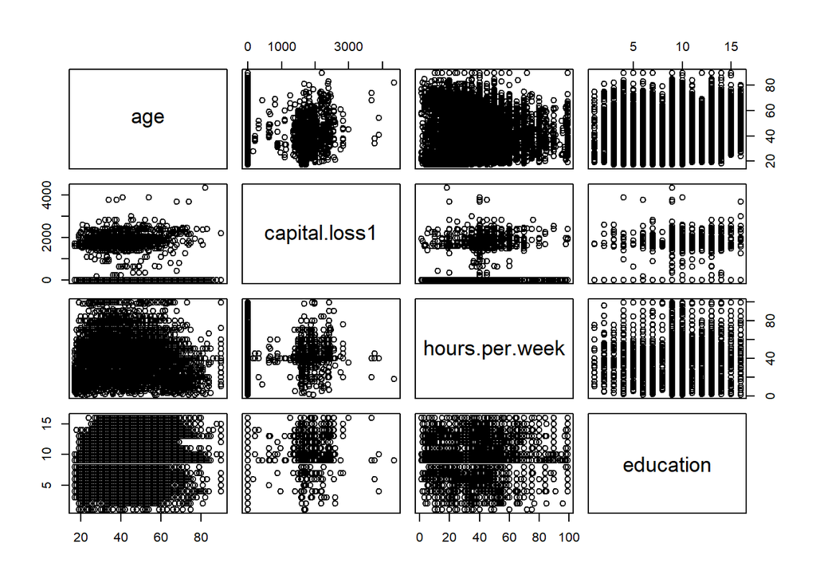

```r
#therefor the model that we will use is
census.lm <- capital.gain ~ age + workclass + education + capital.loss +   hours.per.week + income
#fixing capital loss and gain
census.data$capital.loss1 <- with(census.data, capital.loss + 0.01)
#looking for what to transform
pairs(census.data[c('age', 'capital.loss1', 'hours.per.week', 'education')])
```

```r
#transform numeric predictors
trans.census <- powerTransform(cbind(capital.loss1, age, hours.per.week, education) ~ 1, census.data)
summary(trans.census)
```

```
## bcPower Transformations to Multinormality
##                Est Power Rounded Pwr Wald Lwr Bnd Wald Upr Bnd
## capital.loss1    -1.7450       -1.74      -1.7647      -1.7253
## age               0.1142        0.11       0.0824       0.1460
## hours.per.week    0.9548        0.95       0.9354       0.9743
## education         1.3360        1.34       1.3065       1.3655
##
## Likelihood ratio test that transformation parameters are equal to 0
##  (all log transformations)
##                                  LRT df       pval
## LR test, lambda = (0 0 0 0) 146642.4  4 < 2.22e-16
##
## Likelihood ratio test that no transformations are needed
##                                  LRT df       pval
## LR test, lambda = (1 1 1 1) 675516.8  4 < 2.22e-16
```

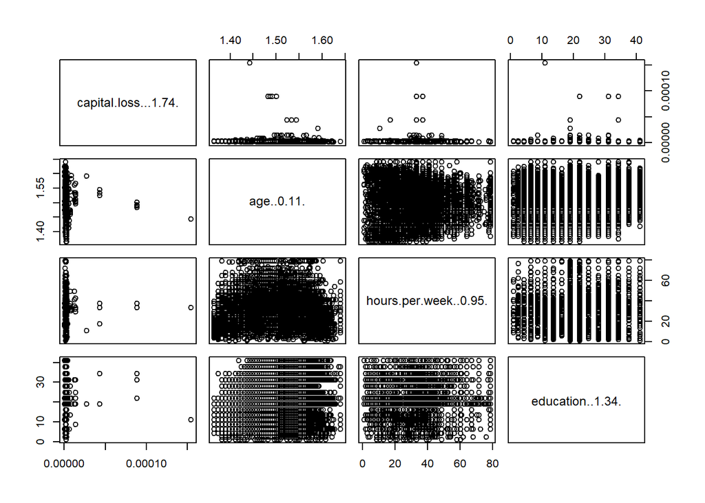

```r
#new transformations
census.trans <- with(census.data, data.frame(capital.loss^(-1.74), age^(.11), hours.per.week^(.95), education^(1.34)))
pairs(census.trans)
```

```r
#fixing capital.gain
capital.gain1 <- with(census.data, capital.gain + 0.01)
#transforming response
#census.power <- powerTransform(capital.gain~.,census.trans)
#summary(census.power)
#therefore capital.gain^(-.88) ~ capital.loss^(-1.74) + age^(.11) +      hours.per.week^(.95) + education^(1.34) + workclass + income
capital.gain2 <- capital.gain^(-0.88)
capital.loss2 <- capital.loss^(-1.74)
age2 <- age^(0.11)
hours.per.week2 <- hours.per.week^(0.95)
education2 <- education^(1.34)
```